# STAT340 Lecture 05: Independence, Conditional Probability and Bayes’ Rule

## How reasonable is independence?

In most applications, it is pretty standard that we assume that our data are drawn *independently and identically distributed* according to some distribution. We say “i.i.d.” for short– get used to this one, because it’s everywhere in statistics and data science!

For example, when we perform regression (as you did in STAT240, and which we’ll revisit in more detail later this semester), we imagine that the observations (i.e., predictor-response pairs) $(X_1,Y_1),(X_2,Y_2),\dots,(X_n,Y_n)$ are independent.

Most standard testing procedures (e.g., the t-test) assume that data are drawn i.i.d.

How reasonable are these assumptions?

Well, of course, in the end, it depends on where the data comes from! We have to draw on what we know about the data, either from our own knowledge or from that of our clients, to assess what assumptions are and aren’t reasonable.

Like most modeling assumptions, we usually acknowledge that independence may not be exactly true, but it’s often a good approximation to the truth!

Of course, we have to be careful.

**Example:** suppose we are modeling the value of a stock over time. We model the stock’s price on days 1, 2, 3, etc as $X_1, X_2, X_3, \dots$. What is wrong with modeling these prices as being independent of one another? Why might it still be a reasonable modeling assumption?

What if instead of considering a stock’s returns on one day after another, we look at a change in stock price on one day, then at the chance 100 days from that, and 100 days from that, and so on? Surely there is still dependence, but a longer time lag between observations *might* make us more willing to accept that our observations are *close* to independent (or at least have much smaller covariance!).

**Example:** suppose we randomly sample 1000 UW-Madison students to participate in a survey, and record their responses as $X_1,X_2,\dots,X_{1000}$. What might be the problem with modeling these responses as being independent? Why might be still be a reasonable modeling assumption?

## Conditional probability

We can’t talk about events and independence without discussing *conditional probability*.

To motivate this, consider the following: suppose I roll a six-sided die. What is the probability that the die lands showing 2? Now, suppose that I don’t tell you the number on the die, but I *do* tell you that the die landed on an even number (i.e., one of 2, 4 or 6). Now what is the probability that the die is showing 2?

**Example: disease screening**

Here’s a more real-world (and more consequential example): suppose we are screening for a rare disease. A patient takes the screening test, and tests positive. What is the probability that the patient has the disease, *given* that they have tested positive for it?

### Introducing conditional probability

These kinds of questions, in which we want to ask about the probability of an event *given* that something else has happened, require that we be able to define a “new kind” of probability, called *conditional probability*.

Let $A$ and $B$ be two events.

- Example: $A$ could be the event that a die lands showing 2 and $B$ is the event that the die landed on an even number.
- Example: $A$ could be the event that our patient has a disease and $B$ is the event that the patient tests positive on a screening test.

Provided that $\Pr[ B ] > 0$, we define the *conditional probability* of $A$ given $B$, written $\Pr[ A \mid B]$, according to
$$\Pr[ A \mid B ] = \frac{ \Pr[ A \cap B ] }{ \Pr[ B ] }.$$
Note that if $\Pr[B] = 0$, then the ratio on the right-hand side is not defined, hence why we demanded that $\Pr[B] > 0$. Later in your career, you’ll see that we can actually define conditional probability in a sensible way even if $\Pr[B] = 0$, but that’s a matter for a later class.

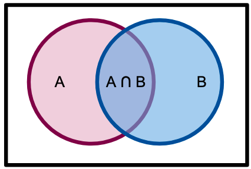

Venn diagram illustrating conditional probability

Let’s try computing one of these conditional probabilities: what is the probability that the die is showing 2 *conditional on the fact* that it landed on an even number?

Well,

- $\Pr[ \text{ even } ] = 1/2$, because there are three even numbers on the die, and all six numbers are equally likely: $3/6 = 1/2$.
- $\Pr[ \text{ die lands 2 } \cap \text{even} ] = \Pr[ \text{ die lands 2 }]$, since $2$ is an even number.

So the conditional probability is
$$\begin{aligned}
\Pr[ \text{ die lands 2 } \mid \text{ even }]
&= \frac{ \Pr[ \text{ die lands 2 } \cap \text{even} ] }{ \Pr[
\text{ even } ] } \\
&= \frac{ \Pr[ \text{ die lands 2 }]}
{ \Pr[ \text{ even } ] } \\
&= \frac{ 1/6 }{ 1/2 } = 1/3.
\end{aligned}$$
This makes sense– *given* that the die lands on an even number, we are choosing from among three outcomes: $\{2,4,6\}$. The probability that we choose $2$ from among these three possible equally-likely outcomes is $1/3$.

### Disease screening

What about our disease testing example? What is the probability that our patient has the disease given that they tested positive?

Well, applying the definition of conditional probability,
$$\Pr[ \text{ disease} \mid \text{ positive test }]
= \frac{ \Pr[ \text{ disease} \cap \text{ positive test }] }{ \Pr[
\text{positive test} ] }$$

Okay, but what is $\Pr[ \text{ positive test} ]$? I guess it’s just the probability that a random person (with the disease or not) tests positive? For that matter, what is $\Pr[ \text{ disease} \cap \text{ positive test }]$? These can be hard events to assign probabilities to! Luckily, there is a famous equation that often gives us a way forward.

## Bayes’ rule

The [Reverend Thomas Bayes](https://en.wikipedia.org/wiki/Thomas_Bayes) was the first to suggest an answer to this issue. Bayes’ rule, as it is now called, tells us how to relate $\Pr[ A \mid B]$ to $\Pr[ B \mid A]$:
$$\Pr[ A \mid B ] = \frac{ \Pr[ B \mid A ] \Pr[ A ]}{ \Pr[ B ]}.$$

This is useful, because it is often easier to write one or the other of these two probabilities.

Applying this to our disease screening example,
$$\Pr[ \text{ disease} \mid \text{ positive test }]
=
\frac{ \Pr[\text{ positive test } \mid \text{ disease}]
\Pr[ \text{ disease}]}
{ \Pr[ \text{ positive test } ] }$$

The advantage of using Bayes’ rule in this context is that the probabilities appearing on the right-hand side are all straight-forward to think about (and estimate!).

- $\Pr[ \text{ disease}]$ is the just the probability that a randomly-selected person has the disease. We could estimate this probability by randomly selecting a random group of people and determining if they have the disease (hopefully not using the screening test we are already using…).
- $\Pr[\text{ positive test } \mid \text{ disease}]$ is the probability that when we give our screening test to a patient who has the disease in question, the test returns positive. This is often called the [sensitivity](https://en.wikipedia.org/wiki/Sensitivity_and_specificity) of a test, a term you may recall hearing frequently in the early days of the COVID-19 pandemic.
- $\Pr[ \text{ positive test } ]$ is just the probability that a test given to a (presumably randomly selected) person returns a positive result. We just said about that this is the hard thing to estimate. In your homework, you’ll explore one way to get at this quantity, but for now we’ll have to just assume that we can estimate it somehow or other.

## Example: testing for a rare disease

Suppose that we are testing for a rare disease, say,
$$\Pr[ \text{ disease}] = \frac{1}{10^6},$$

and suppose that a positive test is also rare, in keeping with the fact that our disease is rare and our test presumably has a low false positive rate:
$$\Pr[ \text{ positive test} ] = 1.999*10^{-6}$$
Note that this probability actually depends on the *sensitivity* $\Pr[\text{ positive test } \mid \text{ disease}]$ and the *specificity* $1-\Pr[\text{ positive test } \mid \text{ healthy}]$ of our test. You’ll explore this part more on your homework, but we’re just going to take this number as given for now.

Finally, let’s suppose that our test is 99.99% accurate:
$$\Pr[\text{ positive test } \mid \text{ disease}]
= 0.9999 = 1-10^{-4}$$

To recap,
$$\begin{aligned}
\Pr[ \text{ disease}] &= \frac{1}{10^6} \\
\Pr[ \text{ positive test} ] &= 1.999*10^{-6} \\
\Pr[\text{ positive test } \mid \text{ disease}]
&= 0.9999.
\end{aligned}$$

Now, suppose that a patient is given the screening test and receives a positive result. Bayes’ rule tells us
$$\begin{aligned}
\Pr[ \text{ disease} \mid \text{ positive test }]
&=
\frac{ \Pr[\text{ positive test } \mid \text{ disease}]
\Pr[ \text{ disease}]}
{ \Pr[ \text{ positive test } ] }
= \frac{ 0.9999 * 10^{-6} }{ 1.999*10^{-6} } \\
&= 0.5002001.
\end{aligned}$$

So even in light of our positive screening test result, the probability that our patient has the disease in question is still only about 50%!

This is part of why, especially early on in the pandemic when COVID-19 was especially rare, testing for the disease in the absence of symptoms was not considered especially useful.

More generally, this is why most screenings for rare diseases are not done routinely– doctors typically screen for rare diseases only if they have a reason to think a patient is more likely to have that disease for other reasons (e.g., family history of a genetic condition or recent exposure to an infectious disease).

## Example: the Monty Hall Problem

Okay, it’s time for a probability and statistics rite of passage: the Monty Hall problem.

The problem is named after Monty Hall, the original host of the game show [Let’s Make a Deal](https://en.wikipedia.org/wiki/Let%27s_Make_a_Deal).

The setup is as follows: you, the contestant, are faced with three doors. Behind one of the doors is the grand prize (a million dollars, a new car, a MacGuffin; use your imagination). Behind the other two doors are goats (in this hypothetical universe, a goat is not a prize you want; I disagree with this sentiment, but that’s beside the point). You get to choose a door, and you win the prize behind that door.

Here’s a helpful illustration from Wikipedia:

[figure not shown]

Image credit Wikipedia; https://en.wikipedia.org/wiki/Monty_Hall_problem

Suppose that you choose a door at random. Having chosen that door, the host Monty Hall opens one of the other doors to reveal a goat (i.e., not the Grand Prize), and Monty Hall offers you a choice: you can *stick with the door you chose* and win whatever prize is behind that door, *or* you can *switch your choice* to the other door, which Monty Hall has not yet opened.

Should you switch your choice of door?

On first glance, most people agree that it should make no difference– your original choice of door was random, so whether you switch your guess or not, you’re still equally likely to have chosen the door with the Grand Prize.

But this intuition is incorrect! Let’s check with a simulation, first.

```r
generate_game_state <- function() {
  # Generate a random instance of the Monty Hall game.
  # That is, a random assignment of prizes to doors
  # and an initial guess for our contestant.
  # Generate an assignment of prizes/goats to doors.
  # We'll encode the Grand Prize as a 1 and the goats as 0s.
  # Reminder: sample(v) just returns a random permutation
  # of the entries of v.
  prizes <- sample( c(1,0,0) );
  # Now, let's randomly pick a door to guess.
  # We pick door number 1, 2 or 3.
  # Use sample() to choose from {1,2,3} uniformly at random
  doors <- c(1,2,3)
  guess <- sample( doors, size=1);
  # Record the other two doors.
  # x[-c] returns the entries of x NOT in vector c.
  otherdoors <- doors[-guess];

  # Return a list object, which will be easier to work with
  # when we want to access the different pieces of game
  # information
  game <- list(prizes=prizes, guess=guess,
               otherdoors=otherdoors );
  return( game )
}

run_game_noswitch <- function() {
  # Run one iteration of Let's Make a Deal,
  # in which we do NOT switch our guess.

  # Generate a game.
  game <- generate_game_state()
  # Now, Monty Hall has to reveal a door to us.
  # If we were switching our guess, we would need to do some
  # extra work to check some conditions (see below for that),
  # but since we're not switching, let's just cut to the
  # chase and see if we won the prize or not.
  # Remember, game$prizes is a vector of 0s and 1s, encoding
  #     the prizes behind the three doors.
  # game$guess is 1, 2 or 3, encoding which door we guessed
  return( game$prizes[game$guess] )
}

run_game_yesswitch <- function() {
  # Run one iteration of Let's Make a Deal,
  # in which we DO switch our guess.

  # Generate a game.
  game <- generate_game_state()
  guess <- game$guess; # We're going to switch this guess.
  # Now, Monty Hall has to reveal a door to us.
  # To do that, we need to look at the other doors,
  # and reveal that one of them has a goat behind it.
  # game$otherdoors is a vector of length 2, encoding the
  # two doors that we didn't look at.
  # So let's look at them one at a time.
  # Note: there are other, more clever ways to write
  # this code, but this is the simplest implementation
  # to think about, in my opinion.
  if( game$prizes[game$otherdoors[1]]==0 ){
    # The first non-guessed door doesn't have a goat
    # behind it, so Monty Hall shows us the goat behind
    # that door, and we need to switch our guess to the
    # *other* door that we didn't choose.
    guess <- game$otherdoors[2];
  } else {
    # If the Grand Prize is behind otherdoors[1],
    # so that game$otherdoors[1]]==1,
    # then Monty Hall is going to show us a goat behind
    # otherdoors[2], and we have the option to switch our
    # guess to otherdoors[1],
    # and we will exercise that option
    guess <- game$otherdoors[1];
  }
  # Now check if we won the prize!
  return( game$prizes[guess] )
}
```

Okay, we’ve got simulations implemented for both of our two different game strategies. Let’s simulate both of these a bunch of times and compare the long-run average success.

```r
M <- 1e4;
noswitch_wins <- 0;
for(i in 1:M) {
  noswitch_wins <- noswitch_wins + run_game_noswitch()
}

noswitch_wins/M
```

```
## [1] 0.3404
```

Now, let’s see how we do if we switch our guesses.

```r
M <- 1e4;
yesswitch_wins <- 0;
for(i in 1:M) {
  yesswitch_wins <- yesswitch_wins + run_game_yesswitch()
}

yesswitch_wins/M
```

```
## [1] 0.6646
```

Wow! That’s a lot better than the strategy where we don’t switch our guess!

This discrepancy can be explained using Bayes’ rule, but it gets a bit involved (see the [wikipedia page](https://en.wikipedia.org/wiki/Monty_Hall_problem#Bayes'_theorem) if you’re really curious).

Instead, let’s just think about the following: suppose that the Grand Prize is behind door number 1. There are three possibilities, all equally likely (because we chose uniformly at random among the three doors):

1. **We pick door 1.** We have chosen the door with the Grand Prize behind it. In this situation, the other two doors both have goats behind them, and Monty Hall reveals one of those two goats to us. In this situation, we (mistakenly, so sad!) switch our Grand Prize door for a goat door and we lose.
2. **We pick door 2.** We have chosen a door with a goat behind it. Of the other two doors, only one has a goat, door 3. Monty Hall shows us the goat behind that door, and we switch our guess to the *other* door, door 1, which has the Grand Prize behind it. Hooray!
3. **We pick door 3.** We have chosen a door with a goat behind it. Of the other two doors, only one has a goat, door 2. Monty Hall shows us the goat behind that door, and we switch our guess to the *other* door, door 1, which has the Grand Prize behind it. Hooray!

So, of the three equally likely situations, we win the Grand Prize in two of them, and our probability of winning is thus $2/3$. Compare that with our $1/3$ probability of winning in the situation where we don’t switch doors. Not bad!

The important point here is that our decision to switch doors is made *conditional* upon the information from Monty Hall that eliminates one of the three doors for us.